# ShowMeMyLegend

Yutong

9/10/2018

The csv file contains the how many refugees the US planed to recieve and how many the US admitted over the past decade. I want to draw a bar chart, showing the number of refugee ceilings every year, and a line chart of actual arrival numbers, and lay the two charts together to make a comparison.

First, some data cleaning. I tried to plot the bar chart just to see how it looked like, when I noticed that the legend didn’t pop up automatically. So, I googled it and now I’m trying to use ‘r reshape’ library to do the trick.Here I need to introduce two new terms: wide-term and long-term.

In short, these are two ways to structure data. With wide-term, you have, for example, the first row of the name of variables (factors), and you put values under each column according to their catagories.

```r
library(ggplot2)
library(reshape2)
df <- read.csv('ceiling.csv')
names(df) <- tolower(names(df))
head(df)
```

```
##   year   cap admitted
## 1 2008 80000    60191
## 2 2009 80000    74654
## 3 2010 80000    73311
## 4 2011 80000    56424
## 5 2012 76000    58238
## 6 2013 70000    69926
```

With long-term, each variable has a value: (So, a sheet of data in long-term, instead of wide-term, is generally longer.And wide-term sheet are usually expand more space. That’s how I remember these terms.)

```r
dfl <- melt(df) #data frame long-term
dfl
```

```
##    variable value
## 1      year  2008
## 2      year  2009
## 3      year  2010
## 4      year  2011
## 5      year  2012
## 6      year  2013
## 7      year  2014
## 8      year  2015
## 9      year  2016
## 10     year  2017
## 11     year  2018
## 12      cap 80000
## 13      cap 80000
## 14      cap 80000
```

[output cut: 19 more lines]

In many cases, you need to tell ‘r melt’ “ID Variables” so as to keep the variables that you want to treat as indicators of your data untouched. These ID Variables are like the attributes to the value, so you don’t want to mess with them. The code looks like this:

```r
dfl<- melt(df, id.vars ="year")
colnames(dfl) <- c('year','type','number')
dfl
```

```
##    year     type number
## 1  2008      cap  80000
## 2  2009      cap  80000
## 3  2010      cap  80000
## 4  2011      cap  80000
## 5  2012      cap  76000
## 6  2013      cap  70000
## 7  2014      cap  70000
## 8  2015      cap  70000
## 9  2016      cap  85000
## 10 2017      cap  50000
## 11 2018      cap  45000
## 12 2008 admitted  60191
## 13 2009 admitted  74654
## 14 2010 admitted  73311
## 15 2011 admitted  56424
## 16 2012 admitted  58238
## 17 2013 admitted  69926
## 18 2014 admitted  69987
## 19 2015 admitted  69933
## 20 2016 admitted  84994
## 21 2017 admitted  53716
## 22 2018 admitted   8635
```

Now, the dataframe looks like what I need. The data breaks down by each year, that is to say, we can find two numbers - one for the ceiling and one for the admission - for each year since 2008. (Just a tip, we can also manipulate the column names with ‘r melt()’ by adding ‘r variable.name = ’catagory_number’, value.name = ‘number’)’ Now let’s try to play with our modified dataset. Start from an easy one, let’s make a gourped-bar chart!

```r
library (ggplot2)
library (ggthemes)
library (scales)

head(dfl)
```

```
##   year type number
## 1 2008  cap  80000
## 2 2009  cap  80000
## 3 2010  cap  80000
## 4 2011  cap  80000
## 5 2012  cap  76000
## 6 2013  cap  70000
```

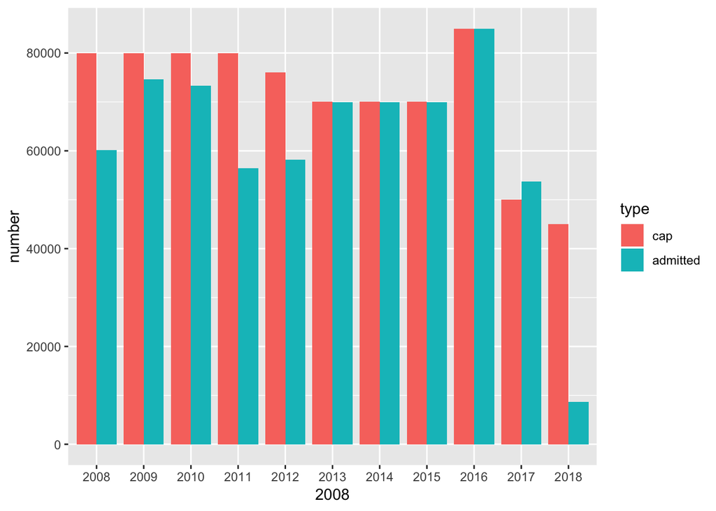

```r
ggplot(dfl, aes(x=factor(dfl$year), y=number, fill = type))+
  geom_bar(position = 'dodge', stat = "identity", width=0.85)+
  scale_x_discrete(dfl$year)
```

Here, I made some twists for the x variable so that each year will show up properly. R uses a different class of variable called *factor* which, according to my understanding, is an indicator telling R that this is a catagery, and it’s discrete, not continuous. This is important for making tick marks because you call the ‘r scale_x_discrete()’ method to mark the chart. As the name suggests, the x variable has to be discrete. And in order to correctly convert x variable into a ‘r factor’, you need to use the ‘r factor()’ function when you draw the X-Axis. Now let’s change this bar chart into a line chart:

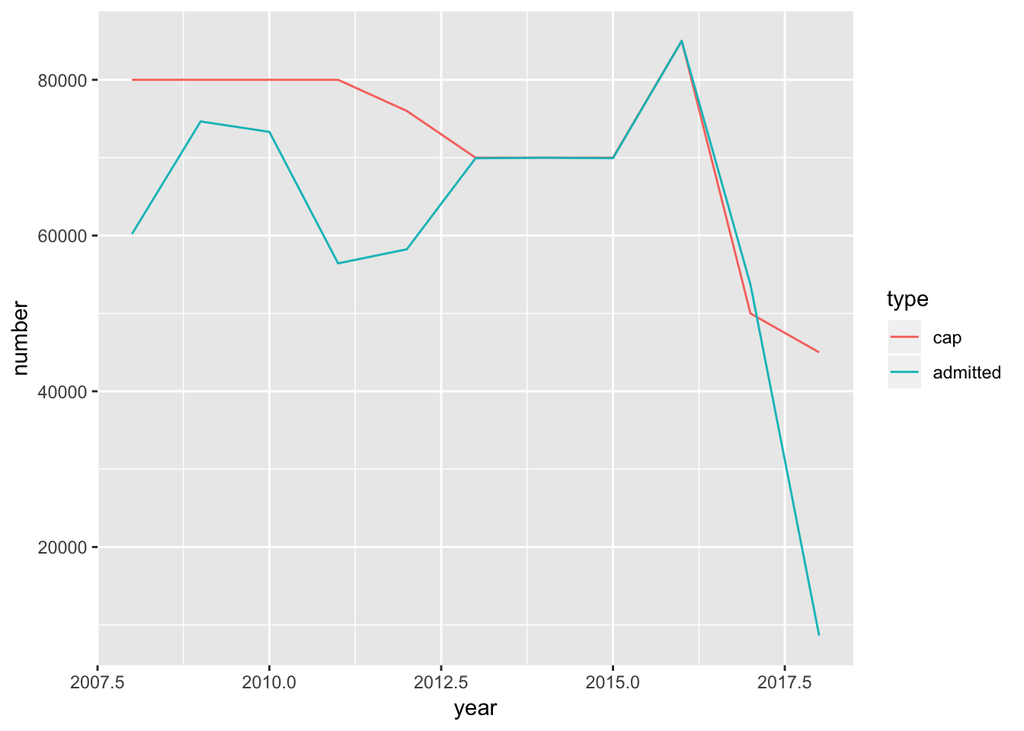

```r
ggplot(dfl, aes(x=year, y=number, group=type))+
  geom_line(aes(color=type))
```

Some take away here. I finally figured out how to use ‘r group’ to break down my data. That is, you pass the name of the attribute to the ‘r group’ to let the computer know that there are more than just 1 lines you want to make. Second, if you want to paint the lines in different color, use the ‘r geom_line(aes(color=’‘))’ function to do this.

```r
library(dplyr)
ADM <- dfl %>%
  filter(type == 'admitted')
```

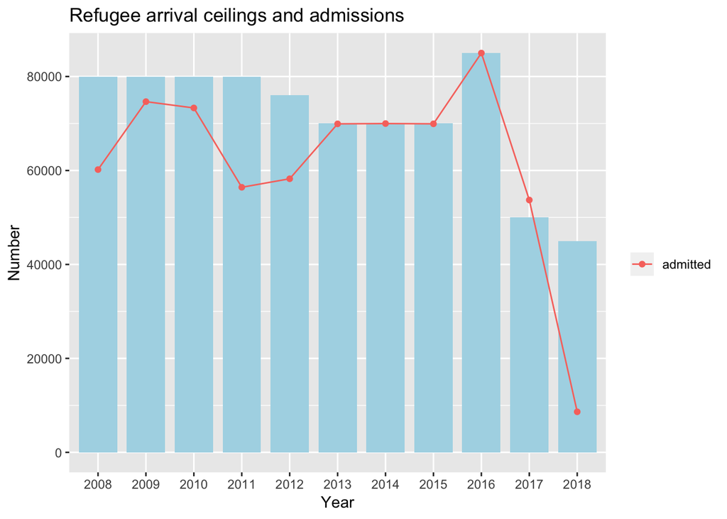

```r
CAP <- dfl%>%
  filter(type =='cap')

#ggplot(dfl, aes(x=factor(year), y=number,group=type,fill=type))+
#  geom_bar(stat='identity',width=0.8)

ggplot(CAP, aes(x=factor(year), y=number))+
  geom_bar(stat='identity',width=0.8,fill='lightblue')+
  geom_line(data=ADM,aes(color=type,group=type))+
  geom_point(data=ADM,aes(color=type))+
  labs(title='Refugee arrival ceilings and admissions', x='Year', y='Number',color = '')
```

```r
#number of 2018 is subjected to change since its not the final number.
```

As I played around the data I got from the Refugee Process Center, I found that sometimes the way we organize data could cause some trouble. Therefore, it’s also necessary to know how to reshape data with R. I have mentioned how to use ‘r melt()’ function to convert longer data entries. But I met another problem: duplicate records:

```
##           startdate         enddate    state      FY total     nationality
## 1 From: 01 Oct 2017 To: 30 Sep 2018 Missouri FY 2018   482           Burma
## 2 From: 01 Oct 2017 To: 30 Sep 2018 Missouri FY 2018   482 Dem. Rep. Congo
## 3 From: 01 Oct 2017 To: 30 Sep 2018 Missouri FY 2018   482         Eritrea
## 4 From: 01 Oct 2017 To: 30 Sep 2018 Missouri FY 2018   482        Ethiopia
## 5 From: 01 Oct 2016 To: 30 Sep 2017 Missouri FY 2017 1,227         Burundi
## 6 From: 01 Oct 2016 To: 30 Sep 2017 Missouri FY 2017 1,227 Dem. Rep. Congo
##   number_nation reset_city number_city total_city
## 1            47   Columbia           9        104
## 2           307   Columbia          74        104
## 3            36   Columbia          20        104
## 4             6   Columbia           1        104
## 5             2   Columbia           2        122
## 6           332   Columbia          49        122
```

As you can see in the table above, the last column keeps how many refugees arrived in Columbia, MO in each fiscal year. But there are obviously duplicated numbers. In order to get the number of each year only once, I used ’r duplicated()’function to find out all the duplicated records.

Finally, ‘r df[!duplicated(df$total_city),]’ can eliminate all the duplicated (entries with true boolen values) and return all the unique entries. But the original data frame won’t be changed, that is to say, you have to pass the result to a new data frame so that you could use the data frame after. Here I passed the result to a new data frame called dftotal_city.

```
##  [1] FALSE  TRUE  TRUE  TRUE FALSE  TRUE  TRUE  TRUE  TRUE  TRUE  TRUE
## [12]  TRUE FALSE  TRUE  TRUE  TRUE  TRUE  TRUE  TRUE  TRUE  TRUE  TRUE
## [23]  TRUE  TRUE FALSE  TRUE  TRUE  TRUE  TRUE  TRUE FALSE  TRUE  TRUE
## [34]  TRUE  TRUE  TRUE  TRUE FALSE  TRUE  TRUE  TRUE  TRUE  TRUE  TRUE
## [45]  TRUE FALSE  TRUE  TRUE  TRUE  TRUE  TRUE  TRUE FALSE  TRUE  TRUE
## [56]  TRUE FALSE  TRUE  TRUE  TRUE  TRUE  TRUE  TRUE FALSE  TRUE  TRUE
## [67]  TRUE  TRUE  TRUE  TRUE FALSE  TRUE  TRUE  TRUE  TRUE  TRUE  TRUE
## [78]  TRUE  TRUE  TRUE  TRUE  TRUE  TRUE  TRUE  TRUE  TRUE FALSE  TRUE
## [89]  TRUE  TRUE FALSE FALSE  TRUE FALSE FALSE
```

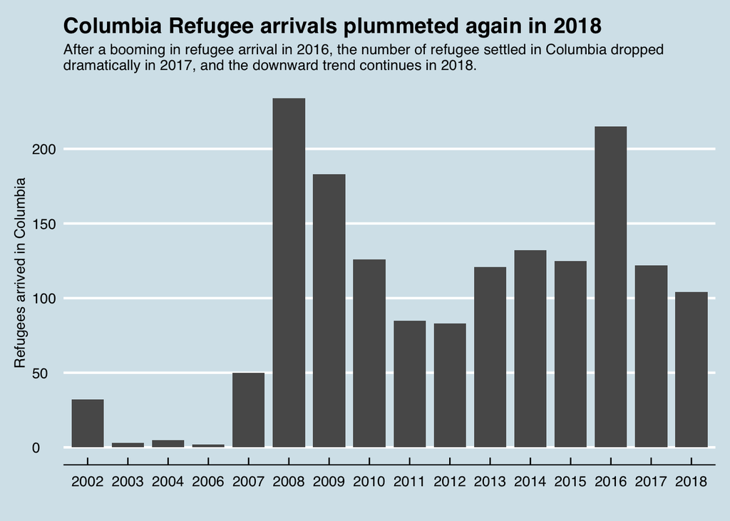